# Bank Churn Prediction

## Objective

Given a Bank customer, build a neural network-based classifier that can determine whether they will leave or not in the next 6 months.

## Context

Businesses like banks that provide service have to worry about the problem of 'Churn' i.e. customers leaving and joining another service provider. It is important to understand which aspects of the service influence a customer's decision in this regard. Management can concentrate efforts on the improvement of service, keeping in mind these priorities.

## Data Description

The case study is from an open-source dataset from Kaggle. The dataset contains 10,000 sample points with 14 distinct features such as CustomerId, CreditScore, Geography, Gender, Age, Tenure, Balance, etc. Link to the Kaggle project site: https://www.kaggle.com/barelydedicated/bank-customer-churn-modeling

## Data Dictionary

- RowNumber: Row number.
- CustomerId: Unique identification key for different customers.
- Surname: Surname of the customer
- Credit Score: Credit score is a measure of an individual's ability to pay back the borrowed amount. It is the numerical representation of their creditworthiness. A credit score is a 3-digit number that falls in the range of 300-900, 900 being the highest.
- Geography: The country to which the customer belongs.
- Gender: The gender of the customer.
- Age: Age of the customer.
- Tenure: The period of time a customer has been associated with the bank.
- Balance: The account balance (the amount of money deposited in the bank account) of the customer.
- NumOfProducts: How many accounts, bank account affiliated products the person has.
- HasCrCard: Does the customer have a credit card through the bank?
- IsActiveMember: Subjective, but for the concept
- EstimatedSalary: Estimated salary of the customer.
- Exited: Did they leave the bank after all?

## Points Distribution

The points distribution for this case is as follows:

1. Read the dataset
2. Drop the columns which are unique for all users like IDs (5 points)
3. Perform bivariate analysis and give your insights from the same (5 points)
4. Distinguish the feature and target set and divide the data set into training and test sets (5 points)
5. Normalize the train and test data (10points)
6. Initialize & build the model. Identify the points of improvement and implement the same. (20)
7. Predict the results using 0.5 as a threshold (10points)
8. Print the Accuracy score and confusion matrix (5 points)

```python
import numpy as np
import pandas as pd
import seaborn as sns
from sklearn.preprocessing import MinMaxScaler
from sklearn.model_selection import train_test_split
from sklearn.preprocessing import StandardScaler
from sklearn import metrics
from matplotlib import pyplot as plt
import tensorflow as tf
from tensorflow.keras import Sequential
from tensorflow.keras.layers import Dense
%matplotlib inline
```

```python
df = pd.read_csv('bank.csv')
df.head()
```

|  | RowNumber | CustomerId | Surname | CreditScore | Geography | Gender | Age | Tenure | Balance | NumOfProducts | HasCrCard | IsActiveMember | EstimatedSalary | Exited |
| --- | --- | --- | --- | --- | --- | --- | --- | --- | --- | --- | --- | --- | --- | --- |
| 0 | 1 | 15634602 | Hargrave | 619 | France | Female | 42 | 2 | 0.00 | 1 | 1 | 1 | 101348.88 | 1 |
| 1 | 2 | 15647311 | Hill | 608 | Spain | Female | 41 | 1 | 83807.86 | 1 | 0 | 1 | 112542.58 | 0 |
| 2 | 3 | 15619304 | Onio | 502 | France | Female | 42 | 8 | 159660.80 | 3 | 1 | 0 | 113931.57 | 1 |
| 3 | 4 | 15701354 | Boni | 699 | France | Female | 39 | 1 | 0.00 | 2 | 0 | 0 | 93826.63 | 0 |
| 4 | 5 | 15737888 | Mitchell | 850 | Spain | Female | 43 | 2 | 125510.82 | 1 | 1 | 1 | 79084.10 | 0 |

```python
df.shape
```

```
(10000, 14)
```

### Insights

- 14 columns
- 10,000 rows
- rather large dataset, which is good for DNN
- however, 3 columns - RowNumber, CustomerId, Surname - are used to ID the customer in some form or fashion and will not be needed
- "Exited" is the target variable, and since it is binary, this will be a classification problem

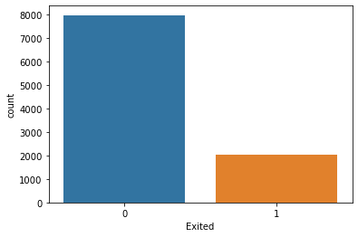

```python
# df.Exited.value_counts()
sns.countplot(x='Exited',data=df)
```

```python
# drop RowNumber, CustomerId, Surname
df.drop(df.iloc[:, 0:3], inplace = True, axis = 1)
df.head()
```

|  | CreditScore | Geography | Gender | Age | Tenure | Balance | NumOfProducts | HasCrCard | IsActiveMember | EstimatedSalary | Exited |
| --- | --- | --- | --- | --- | --- | --- | --- | --- | --- | --- | --- |
| 0 | 619 | France | Female | 42 | 2 | 0.00 | 1 | 1 | 1 | 101348.88 | 1 |
| 1 | 608 | Spain | Female | 41 | 1 | 83807.86 | 1 | 0 | 1 | 112542.58 | 0 |
| 2 | 502 | France | Female | 42 | 8 | 159660.80 | 3 | 1 | 0 | 113931.57 | 1 |
| 3 | 699 | France | Female | 39 | 1 | 0.00 | 2 | 0 | 0 | 93826.63 | 0 |
| 4 | 850 | Spain | Female | 43 | 2 | 125510.82 | 1 | 1 | 1 | 79084.10 | 0 |

```python
df.shape
```

```
(10000, 11)
```

```python
df.info()
```

```
<class 'pandas.core.frame.DataFrame'>
RangeIndex: 10000 entries, 0 to 9999
Data columns (total 11 columns):
 #   Column           Non-Null Count  Dtype
---  ------           --------------  -----
 0   CreditScore      10000 non-null  int64
 1   Geography        10000 non-null  object
 2   Gender           10000 non-null  object
 3   Age              10000 non-null  int64
 4   Tenure           10000 non-null  int64
 5   Balance          10000 non-null  float64
 6   NumOfProducts    10000 non-null  int64
 7   HasCrCard        10000 non-null  int64
 8   IsActiveMember   10000 non-null  int64
 9   EstimatedSalary  10000 non-null  float64
 10  Exited           10000 non-null  int64
dtypes: float64(2), int64(7), object(2)
memory usage: 859.5+ KB
```

```python
df.describe()
```

|  | CreditScore | Age | Tenure | Balance | NumOfProducts | HasCrCard | IsActiveMember | EstimatedSalary | Exited |
| --- | --- | --- | --- | --- | --- | --- | --- | --- | --- |
| count | 10000.000000 | 10000.000000 | 10000.000000 | 10000.000000 | 10000.000000 | 10000.00000 | 10000.000000 | 10000.000000 | 10000.000000 |
| mean | 650.528800 | 38.921800 | 5.012800 | 76485.889288 | 1.530200 | 0.70550 | 0.515100 | 100090.239881 | 0.203700 |
| std | 96.653299 | 10.487806 | 2.892174 | 62397.405202 | 0.581654 | 0.45584 | 0.499797 | 57510.492818 | 0.402769 |
| min | 350.000000 | 18.000000 | 0.000000 | 0.000000 | 1.000000 | 0.00000 | 0.000000 | 11.580000 | 0.000000 |
| 25% | 584.000000 | 32.000000 | 3.000000 | 0.000000 | 1.000000 | 0.00000 | 0.000000 | 51002.110000 | 0.000000 |
| 50% | 652.000000 | 37.000000 | 5.000000 | 97198.540000 | 1.000000 | 1.00000 | 1.000000 | 100193.915000 | 0.000000 |
| 75% | 718.000000 | 44.000000 | 7.000000 | 127644.240000 | 2.000000 | 1.00000 | 1.000000 | 149388.247500 | 0.000000 |
| max | 850.000000 | 92.000000 | 10.000000 | 250898.090000 | 4.000000 | 1.00000 | 1.000000 | 199992.480000 | 1.000000 |

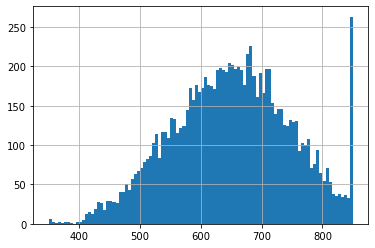

```python
df.CreditScore.hist(bins=100)
```

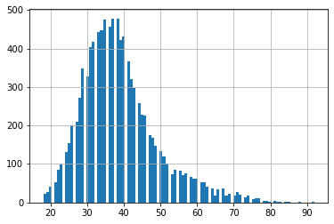

```python
df.Age.hist(bins=100)
```

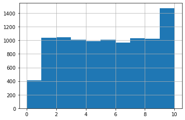

```python
df.Tenure.hist(bins=10)
```

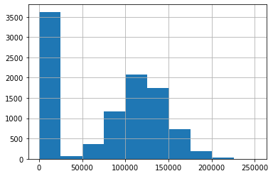

```python
df.Balance.hist(bins=10)
```

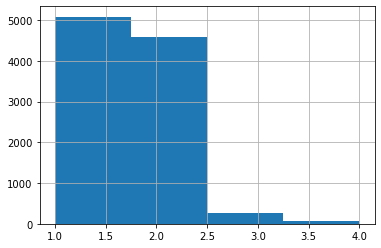

```python
df.NumOfProducts.hist(bins=4)
```

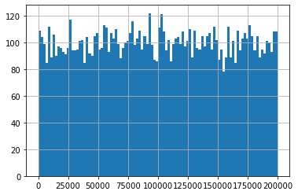

```python
df.EstimatedSalary.hist(bins=100)
```

### Overall Insights

[output not shown]

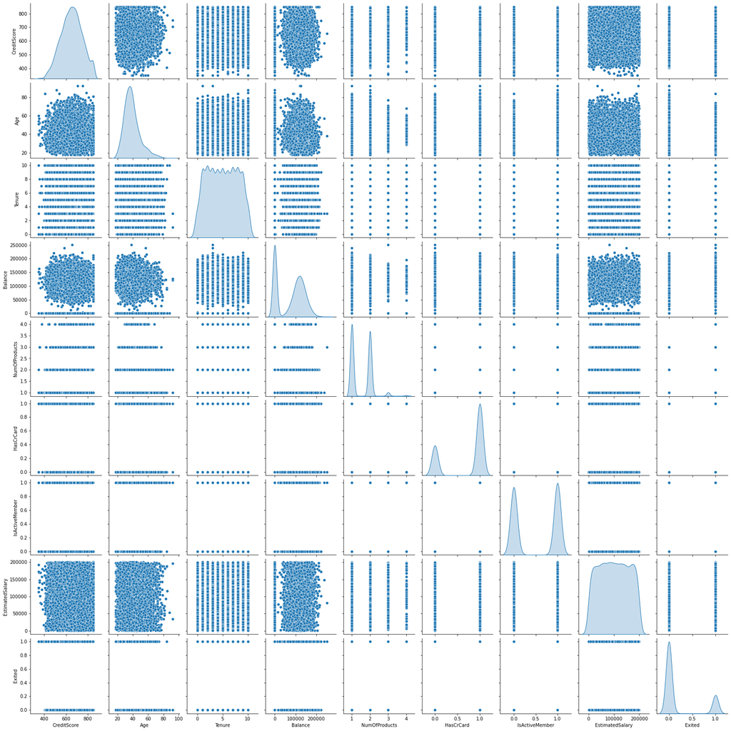

```python
sns.pairplot(df, diag_kind='kde')
```

### Insights

- The $0 Balance line stands out to me - worth investigating.

```python
df.Balance.describe()
```

```
count     10000.000000
mean      76485.889288
std       62397.405202
min           0.000000
25%           0.000000
50%       97198.540000
75%      127644.240000
max      250898.090000
Name: Balance, dtype: float64
```

```python
df_bal = pd.DataFrame(df.Balance)
```

```python
quantiles = [.25, .35, .45, .5]
for quant in quantiles:
    print(df_bal.quantile(quant))
```

```
Balance    0.0
Name: 0.25, dtype: float64
Balance    0.0
Name: 0.35, dtype: float64
Balance    87621.897
Name: 0.45, dtype: float64
Balance    97198.54
Name: 0.5, dtype: float64
```

```python
from numpy import arange

for i in arange(0.35,0.45, 0.01):
#     print(i)
    print(df_bal.quantile(i))
```

```
Balance    0.0
Name: 0.35, dtype: float64
Balance    0.0
Name: 0.36, dtype: float64
Balance    51854.0978
Name: 0.37, dtype: float64
Balance    62069.4548
Name: 0.38, dtype: float64
Balance    68623.5761
Name: 0.39, dtype: float64
Balance    73080.908
Name: 0.4, dtype: float64
Balance    77039.783
Name: 0.41000000000000003, dtype: float64
Balance    79959.4298
Name: 0.42000000000000004, dtype: float64
Balance    82540.23
Name: 0.43000000000000005, dtype: float64
Balance    84842.3724
Name: 0.44000000000000006, dtype: float64
Balance    87621.897
Name: 0.45000000000000007, dtype: float64
```

### Insights

- There is a $0 balance up to the 37th quantile

```python
min_quant = df.Balance.quantile(0.37)
df = df[df.Balance > min_quant]
df.head()
```

|  | CreditScore | Geography | Gender | Age | Tenure | Balance | NumOfProducts | HasCrCard | IsActiveMember | EstimatedSalary | Exited |
| --- | --- | --- | --- | --- | --- | --- | --- | --- | --- | --- | --- |
| 1 | 608 | Spain | Female | 41 | 1 | 83807.86 | 1 | 0 | 1 | 112542.58 | 0 |
| 2 | 502 | France | Female | 42 | 8 | 159660.80 | 3 | 1 | 0 | 113931.57 | 1 |
| 4 | 850 | Spain | Female | 43 | 2 | 125510.82 | 1 | 1 | 1 | 79084.10 | 0 |
| 5 | 645 | Spain | Male | 44 | 8 | 113755.78 | 2 | 1 | 0 | 149756.71 | 1 |
| 7 | 376 | Germany | Female | 29 | 4 | 115046.74 | 4 | 1 | 0 | 119346.88 | 1 |

```python
df.shape
```

```
(6300, 11)
```

```python
df.describe()
```

|  | CreditScore | Age | Tenure | Balance | NumOfProducts | HasCrCard | IsActiveMember | EstimatedSalary | Exited |
| --- | --- | --- | --- | --- | --- | --- | --- | --- | --- |
| count | 6300.000000 | 6300.000000 | 6300.000000 | 6300.000000 | 6300.000000 | 6300.000000 | 6300.000000 | 6300.000000 | 6300.000000 |
| mean | 651.027937 | 39.180952 | 4.982381 | 120871.608783 | 1.385238 | 0.698254 | 0.513175 | 100684.730959 | 0.239365 |
| std | 97.087831 | 10.462853 | 2.910668 | 28855.145327 | 0.575472 | 0.459052 | 0.499866 | 57380.311828 | 0.426730 |
| min | 350.000000 | 18.000000 | 0.000000 | 51949.950000 | 1.000000 | 0.000000 | 0.000000 | 11.580000 | 0.000000 |
| 25% | 584.000000 | 32.000000 | 2.000000 | 101100.140000 | 1.000000 | 0.000000 | 0.000000 | 51671.765000 | 0.000000 |
| 50% | 652.000000 | 38.000000 | 5.000000 | 120467.045000 | 1.000000 | 1.000000 | 1.000000 | 101154.790000 | 0.000000 |
| 75% | 718.000000 | 44.000000 | 8.000000 | 139725.310000 | 2.000000 | 1.000000 | 1.000000 | 149578.672500 | 0.000000 |
| max | 850.000000 | 92.000000 | 10.000000 | 250898.090000 | 4.000000 | 1.000000 | 1.000000 | 199970.740000 | 1.000000 |

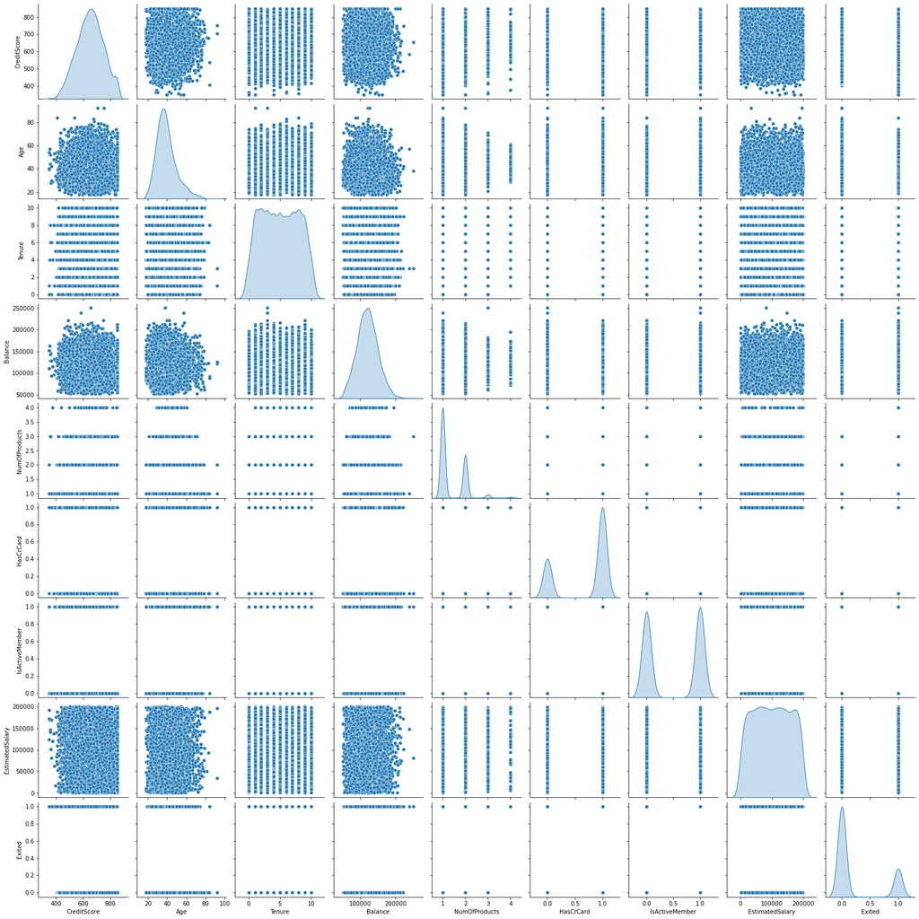

```python
sns.pairplot(df, diag_kind='kde')
```

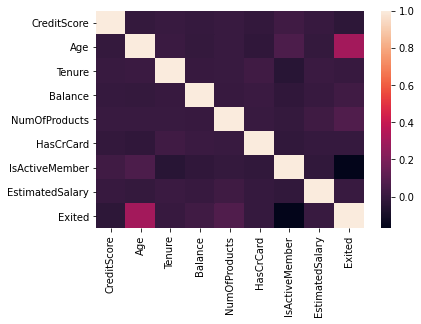

```python
sns.heatmap(df.corr())
```

### Insights

- IsActiveMember has the lowest correlation with Exited
- Age has the highest

```python
df.drop(['IsActiveMember'], inplace = True, axis=1)
df.head()
```

|  | CreditScore | Geography | Gender | Age | Tenure | Balance | NumOfProducts | HasCrCard | EstimatedSalary | Exited |
| --- | --- | --- | --- | --- | --- | --- | --- | --- | --- | --- |
| 1 | 608 | Spain | Female | 41 | 1 | 83807.86 | 1 | 0 | 112542.58 | 0 |
| 2 | 502 | France | Female | 42 | 8 | 159660.80 | 3 | 1 | 113931.57 | 1 |
| 4 | 850 | Spain | Female | 43 | 2 | 125510.82 | 1 | 1 | 79084.10 | 0 |
| 5 | 645 | Spain | Male | 44 | 8 | 113755.78 | 2 | 1 | 149756.71 | 1 |
| 7 | 376 | Germany | Female | 29 | 4 | 115046.74 | 4 | 1 | 119346.88 | 1 |

```python
# store only continuous variables + target variable (Exited) into dataframe for analysis
df_plot = df.drop(['Geography', 'Gender', 'HasCrCard'], axis = 1)
df_plot.head()
```

|  | CreditScore | Age | Tenure | Balance | NumOfProducts | EstimatedSalary | Exited |
| --- | --- | --- | --- | --- | --- | --- | --- |
| 1 | 608 | 41 | 1 | 83807.86 | 1 | 112542.58 | 0 |
| 2 | 502 | 42 | 8 | 159660.80 | 3 | 113931.57 | 1 |
| 4 | 850 | 43 | 2 | 125510.82 | 1 | 79084.10 | 0 |
| 5 | 645 | 44 | 8 | 113755.78 | 2 | 149756.71 | 1 |
| 7 | 376 | 29 | 4 | 115046.74 | 4 | 119346.88 | 1 |

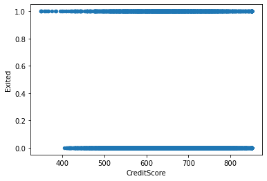

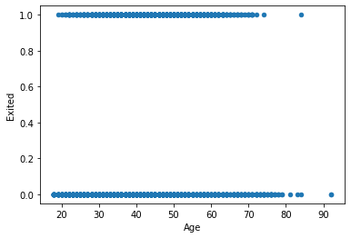

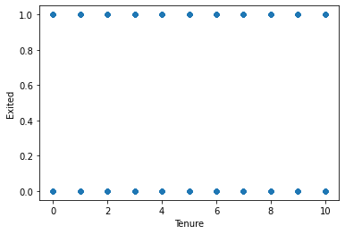

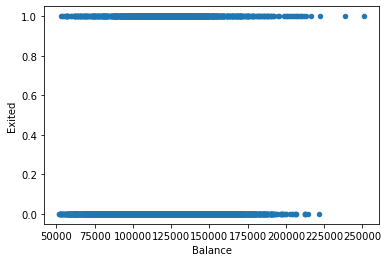

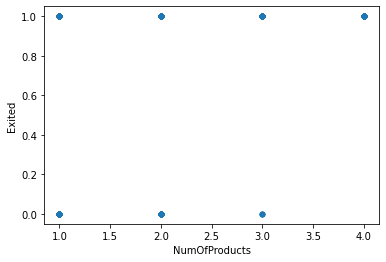

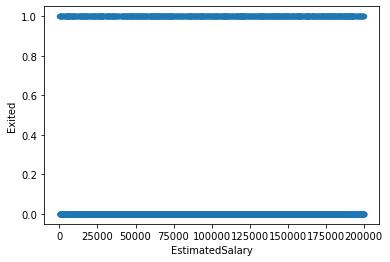

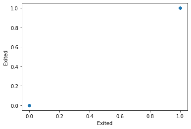

```python
for col in df_plot.columns:
    df_plot.plot.scatter(x=col, y='Exited')
```

### Insights

```python
df['Geography'].unique()
```

```
array(['Spain', 'France', 'Germany'], dtype=object)
```

```python
# one-hot encoding of Geography(categorical variable)
df = pd.get_dummies(df, columns=['Geography'])
df.head()
```

|  | CreditScore | Gender | Age | Tenure | Balance | NumOfProducts | HasCrCard | EstimatedSalary | Exited | Geography_France | Geography_Germany | Geography_Spain |
| --- | --- | --- | --- | --- | --- | --- | --- | --- | --- | --- | --- | --- |
| 1 | 608 | Female | 41 | 1 | 83807.86 | 1 | 0 | 112542.58 | 0 | 0 | 0 | 1 |
| 2 | 502 | Female | 42 | 8 | 159660.80 | 3 | 1 | 113931.57 | 1 | 1 | 0 | 0 |
| 4 | 850 | Female | 43 | 2 | 125510.82 | 1 | 1 | 79084.10 | 0 | 0 | 0 | 1 |
| 5 | 645 | Male | 44 | 8 | 113755.78 | 2 | 1 | 149756.71 | 1 | 0 | 0 | 1 |
| 7 | 376 | Female | 29 | 4 | 115046.74 | 4 | 1 | 119346.88 | 1 | 0 | 1 | 0 |

```python
df['Gender'].unique()
```

```
array(['Female', 'Male'], dtype=object)
```

```python
# convert gender into binary instead of one-hot encoding
gender = {'Male': 1,'Female': 0}
df.Gender = [gender[item] for item in df.Gender]
df.head()
```

|  | CreditScore | Gender | Age | Tenure | Balance | NumOfProducts | HasCrCard | EstimatedSalary | Exited | Geography_France | Geography_Germany | Geography_Spain |
| --- | --- | --- | --- | --- | --- | --- | --- | --- | --- | --- | --- | --- |
| 1 | 608 | 0 | 41 | 1 | 83807.86 | 1 | 0 | 112542.58 | 0 | 0 | 0 | 1 |
| 2 | 502 | 0 | 42 | 8 | 159660.80 | 3 | 1 | 113931.57 | 1 | 1 | 0 | 0 |
| 4 | 850 | 0 | 43 | 2 | 125510.82 | 1 | 1 | 79084.10 | 0 | 0 | 0 | 1 |
| 5 | 645 | 1 | 44 | 8 | 113755.78 | 2 | 1 | 149756.71 | 1 | 0 | 0 | 1 |
| 7 | 376 | 0 | 29 | 4 | 115046.74 | 4 | 1 | 119346.88 | 1 | 0 | 1 | 0 |

```python
df.dtypes
```

```
CreditScore            int64
Gender                 int64
Age                    int64
Tenure                 int64
Balance              float64
NumOfProducts          int64
HasCrCard              int64
EstimatedSalary      float64
Exited                 int64
Geography_France       uint8
Geography_Germany      uint8
Geography_Spain        uint8
dtype: object
```

```python
for col in df.columns:
#     print(df[col].dtype=='uint8')
    if df[col].dtype=='uint8':
        df[col] = df[col].astype('int64')
```

```python
df.dtypes
```

```
CreditScore            int64
Gender                 int64
Age                    int64
Tenure                 int64
Balance              float64
NumOfProducts          int64
HasCrCard              int64
EstimatedSalary      float64
Exited                 int64
Geography_France       int64
Geography_Germany      int64
Geography_Spain        int64
dtype: object
```

```python
df.head()
```

|  | CreditScore | Gender | Age | Tenure | Balance | NumOfProducts | HasCrCard | EstimatedSalary | Exited | Geography_France | Geography_Germany | Geography_Spain |
| --- | --- | --- | --- | --- | --- | --- | --- | --- | --- | --- | --- | --- |
| 1 | 608 | 0 | 41 | 1 | 83807.86 | 1 | 0 | 112542.58 | 0 | 0 | 0 | 1 |
| 2 | 502 | 0 | 42 | 8 | 159660.80 | 3 | 1 | 113931.57 | 1 | 1 | 0 | 0 |
| 4 | 850 | 0 | 43 | 2 | 125510.82 | 1 | 1 | 79084.10 | 0 | 0 | 0 | 1 |
| 5 | 645 | 1 | 44 | 8 | 113755.78 | 2 | 1 | 149756.71 | 1 | 0 | 0 | 1 |
| 7 | 376 | 0 | 29 | 4 | 115046.74 | 4 | 1 | 119346.88 | 1 | 0 | 1 | 0 |

```python
# # scale continuous variables
# cont_var = ['CreditScore', 'Age', 'Balance', 'EstimatedSalary']
# scaler_minmax = MinMaxScaler()
# df[cont_var] = scaler_minmax.fit_transform(df[cont_var])
# df.head()
```

```python
# categorical_cols = ['Gender', 'NumOfProducts', 'HasCrCard']
# for col in categorical_cols:
#     df[col] = df[col].astype('category')
```

```python
df.dtypes
```

```
CreditScore            int64
Gender                 int64
Age                    int64
Tenure                 int64
Balance              float64
NumOfProducts          int64
HasCrCard              int64
EstimatedSalary      float64
Exited                 int64
Geography_France       int64
Geography_Germany      int64
Geography_Spain        int64
dtype: object
```

```python
df.shape
```

```
(6300, 12)
```

```python
df.head()
```

|  | CreditScore | Gender | Age | Tenure | Balance | NumOfProducts | HasCrCard | EstimatedSalary | Exited | Geography_France | Geography_Germany | Geography_Spain |
| --- | --- | --- | --- | --- | --- | --- | --- | --- | --- | --- | --- | --- |
| 1 | 608 | 0 | 41 | 1 | 83807.86 | 1 | 0 | 112542.58 | 0 | 0 | 0 | 1 |
| 2 | 502 | 0 | 42 | 8 | 159660.80 | 3 | 1 | 113931.57 | 1 | 1 | 0 | 0 |
| 4 | 850 | 0 | 43 | 2 | 125510.82 | 1 | 1 | 79084.10 | 0 | 0 | 0 | 1 |
| 5 | 645 | 1 | 44 | 8 | 113755.78 | 2 | 1 | 149756.71 | 1 | 0 | 0 | 1 |
| 7 | 376 | 0 | 29 | 4 | 115046.74 | 4 | 1 | 119346.88 | 1 | 0 | 1 | 0 |

```python
# split between dependent and independent variables
X = df.drop('Exited', axis=1)
y = df['Exited']
```

```python
# split between training and test data
X_train, X_test, y_train, y_test = train_test_split(X, y, test_size=0.3, random_state=2)
```

```python
X_train
```

|  | CreditScore | Gender | Age | Tenure | Balance | NumOfProducts | HasCrCard | EstimatedSalary | Geography_France | Geography_Germany | Geography_Spain |
| --- | --- | --- | --- | --- | --- | --- | --- | --- | --- | --- | --- |
| 4149 | 623 | 0 | 39 | 1 | 160903.20 | 1 | 0 | 78774.36 | 1 | 0 | 0 |
| 2986 | 570 | 1 | 42 | 0 | 107856.57 | 2 | 1 | 127528.84 | 0 | 1 | 0 |
| 5640 | 477 | 0 | 24 | 2 | 95675.62 | 2 | 0 | 162699.70 | 0 | 1 | 0 |
| 5082 | 724 | 0 | 41 | 4 | 142880.28 | 3 | 0 | 185541.20 | 0 | 0 | 1 |
| 6644 | 556 | 1 | 33 | 3 | 124213.36 | 2 | 1 | 62627.55 | 0 | 1 | 0 |
| ... | ... | ... | ... | ... | ... | ... | ... | ... | ... | ... | ... |
| 1728 | 758 | 0 | 40 | 5 | 93499.82 | 2 | 0 | 123218.81 | 0 | 0 | 1 |
| 3926 | 714 | 1 | 29 | 6 | 92887.13 | 1 | 1 | 69578.49 | 0 | 1 | 0 |
| 5706 | 682 | 0 | 48 | 9 | 101198.01 | 1 | 1 | 49732.90 | 0 | 0 | 1 |
| 9067 | 704 | 1 | 41 | 9 | 62078.21 | 2 | 1 | 129050.67 | 0 | 1 | 0 |
| 4021 | 772 | 0 | 48 | 6 | 108736.52 | 1 | 1 | 184564.67 | 0 | 1 | 0 |

4410 rows × 11 columns

```python
X_train.shape, X_test.shape, y_train.shape, y_test.shape
```

```
((4410, 11), (1890, 11), (4410,), (1890,))
```

```python
# standardize data
scaler = StandardScaler().fit(X_train)
X_train= scaler.transform(X_train)
X_test = scaler.transform(X_test)
```

```python
X_train
```

```
array([[-0.2949583 , -1.08823234, -0.00861989, ...,  1.21267813,
        -0.80918739, -0.49929128],
       [-0.84062917,  0.91892141,  0.27648309, ..., -0.82462113,
         1.23580768, -0.49929128],
       [-1.7981271 , -1.08823234, -1.4341348 , ..., -0.82462113,
         1.23580768, -0.49929128],
       ...,
       [ 0.31248663, -1.08823234,  0.84668905, ..., -0.82462113,
        -0.80918739,  2.00283889],
       [ 0.53899152,  0.91892141,  0.18144876, ..., -0.82462113,
         1.23580768, -0.49929128],
       [ 1.23909754, -1.08823234,  0.84668905, ..., -0.82462113,
         1.23580768, -0.49929128]])
```

```python
# initialize the constructor
model = Sequential()

# define model architecture, i.e., define neurons and hidden layers
model.add(Dense(100,activation='sigmoid'))
model.add(Dense(100,activation='sigmoid'))
model.add(Dense(100,activation='sigmoid'))
model.add(Dense(100,activation='sigmoid'))
model.add(Dense(1, activation='sigmoid'))

model.compile(loss='binary_crossentropy',optimizer='adam',metrics=['accuracy'])

model.fit(X_train, y_train, epochs=500, batch_size=1000, verbose=0)
```

```
<tensorflow.python.keras.callbacks.History at 0x7fbd878d04c0>
```

```python
loss, acc = model.evaluate(X_test, y_test, verbose=0)
print('Accuracy: %.3f'  % acc)
print('Loss: %.3f' % loss)
```

```
Accuracy: 0.834
Loss: 0.390
```

```python
y_predict = model.predict(X_test)
```

```python
y_predict = (y_predict > 0.5)
y_predict
```

```
array([[False],
       [False],
       [False],
       ...,
       [False],
       [False],
       [False]])
```

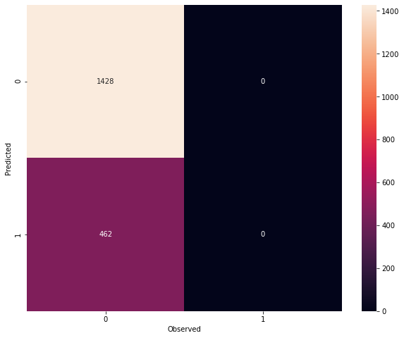

```python
y_pred = []
for val in y_predict:
    y_pred.append(np.argmax(val))
cm = metrics.confusion_matrix(y_test,y_pred)
plt.figure(figsize=(10,8))
sns.heatmap(cm, annot=True, fmt='d')
plt.ylabel('Predicted')
plt.xlabel('Observed')
```

```python
len(X_test)
```

```
1890
```

```python
cr=metrics.classification_report(y_test,y_pred)
print(cr)
```

```
              precision    recall  f1-score   support

           0       0.76      1.00      0.86      1428
           1       0.00      0.00      0.00       462

    accuracy                           0.76      1890
   macro avg       0.38      0.50      0.43      1890
weighted avg       0.57      0.76      0.65      1890
```